# HDAT9600 Final Team Assignment

Submission deadline - 03-May-2024

2024-05-02

There were 2061 unique patients who contributed to the data set, 1148 (56%) were male and the average age was 67 (IQR: 52 - 78) years old.

**297** of the patients died during their hospital admission.

**Variables with values outside of plausible clinical ranges or logically incorrect were cleaned with imputation of median values**

- `SOFA` should not be negative
- `Length_of_stay` should not be less than 2 given dataset contains stays greater than 48 hours
- `Weight` absurd weight differences and extremely high values

**Variables with Missing Data:**

- `SAPS1`: 96 missing values (4.66% missing) - This is a relatively small proportion of the dataset. Since SAPS-I is an important score for ICU prognosis, it worth imputing these values rather than excluding the variable.
- Blood pressure-related variables (`DiasABP_diff`, `DiasABP_max`, `DiasABP_min`, `NIDiasABP_diff`, `NIDiasABP_max`, `NIDiasABP_min`, `NIMAP_diff`, `NIMAP_max`, `NIMAP_min`, `NISysABP_diff`, `NISysABP_max`, `NISysABP_min`, `SysABP_diff`, `SysABP_max`, `SysABP_min`): All these have a high degree of missingness. Since these are many related variables with substantial missing data, we therefore considered only MAP, given the complete information.
- `Height`: 992 missing values (48.13% missing) - given the high rate of missing values, and low probability of importance to clinical outcome it has been excluded
- Weight-related variables (`Weight_diff`, `Weight_max`, `Weight_min`): 146 missing values (7.08% missing) - Given this is a smaller proportion of missing data and weight is possibly an important variable for analysis it may be worth imputing values.

**Variables to be excluded due to high missing data:** DiasABP_diff, DiasABP_max, DiasABP_min, Height, SysABP_diff, SysABP_max, SysABP_min

**Remaining total missing values in the cleaned data:** 1288

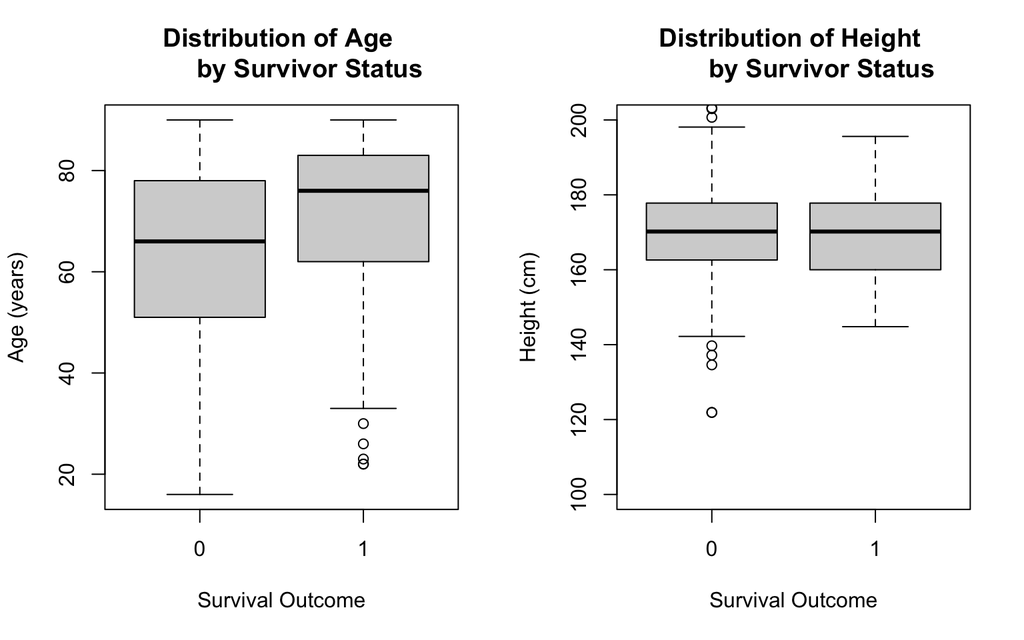

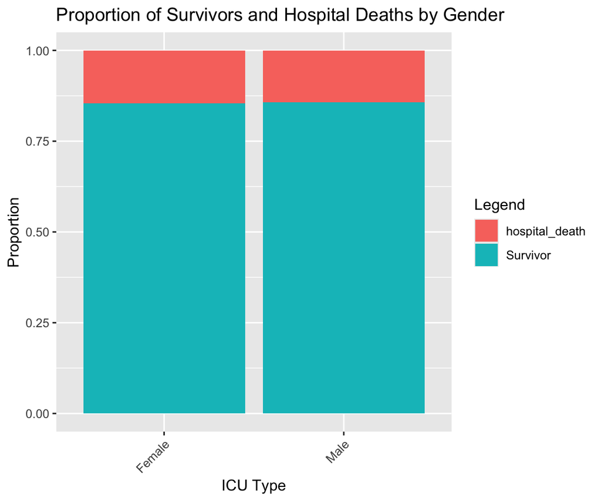

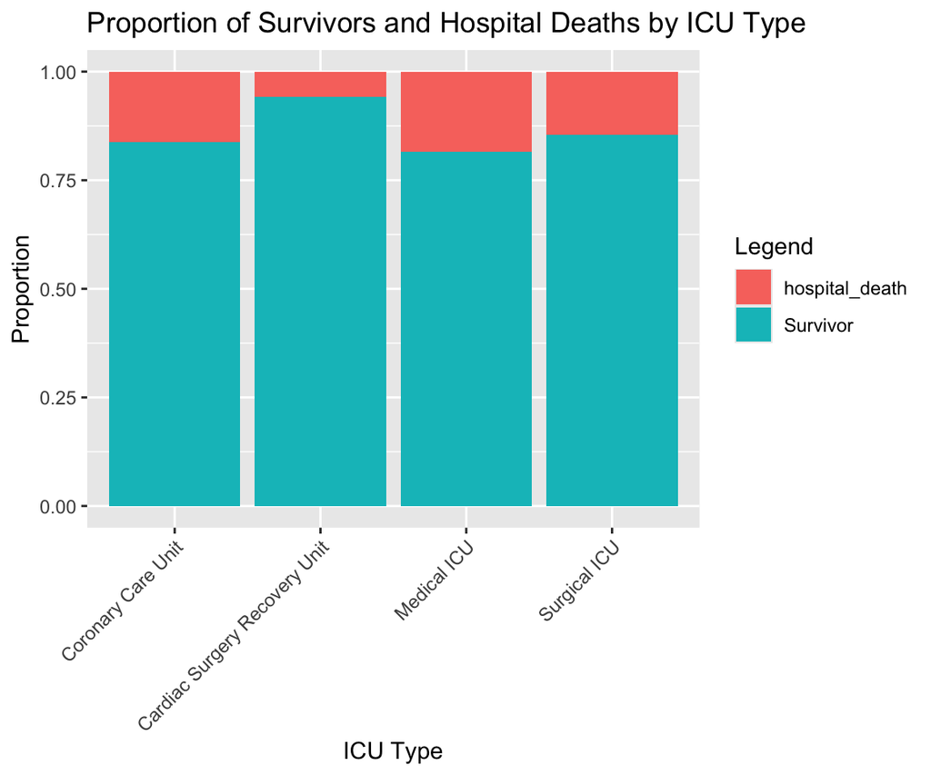

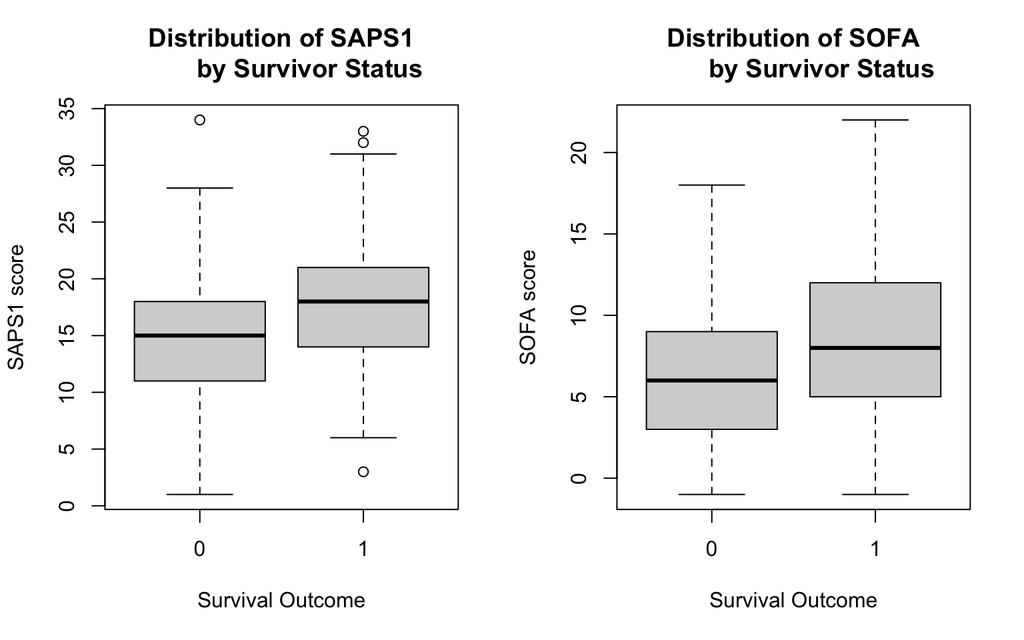

Survival in a hospital ICU is influenced by numerous factors. Older age is often associated with a higher risk of death in an ICU, and this is supported by the box plot showing a notable difference in the distribution of age for survivor and in-hospital death patients. However, the box plot for height indicates there is no significant difference in the distribution of height for survivor and in-hospital death patients, and there is currently no evidence that height or gender has any impact in the outcome of an ICU hospital stay, collectively suggesting this variable is not a useful predictor. While the stacked bar plot for gender shows very similar proportions of survivors/in-hospital deaths for each gender, suggesting it is also not a useful predictor, the stacked bar plot for ICU type showed notably different proportions of survivors/in-hospital deaths per ICU type, with a significantly higher chance of survival in the cardiac surgery recovery unit, suggesting it may have some value as a predictor. The box-plots for SAPS1 and SOFA support that these two variables will be useful predictors by showing that there is a notable difference in the distribution of both SAPS1 and SOFA scores between survivor and in-hospital death patients.

Respiratory function is captured by PaO2, FiO2 and RespRate Coagulation & blood is captured by Platelets, pH and Glucose Liver function is captured by Bilirubin, Albumin, ALP, ALT, AST Cardiovascular system is captured by HR, MAP, TroponinI, TroponinT, Lactate Central nervous system is captured by GCS Renal function is captured by Creatinine, Urine Immune system is captured by Temp, WBC

Each of the 36 clinical measures in the dataset are captured by 3 variables, the minimum value during the first 24 hours in ICU (_min), the maximum value during the first 24 hours in ICU (_max), and the difference between the mean and the most extreme values during the first 24 hours in ICU (_diff). Furthermore, systolic, diastolic and mean arterial blood pressure were measured through both invasive and non-invasive measures. As logistic regression models are based on several assumptions including the assumption of no multicollinearity, which states predictor variables should not be highly correlated with each other, only one of these related variables should be included in the model. Therefore, it is important to determine not only if the clinical measure has a significant effect on the ICU survival outcome, but also which of the related variables is the most representative of this effect and should be included as a predictor.

Elevated levels of Albumin, AST, Bilirubin, BUN, Creatinine, GCS, Glucose, HCO3, Lactate, respiratory rate and urine output are significant predictors of death in an ICU hospital, so the max variables of these clinical measures should be chosen as potential predictors. On the other hand, sudden large changes in heart rate, Na, pH, temperature and non-invasive systolic blood pressure have been found to have a strong association with ICU death, so the _diff variables should be chosen. As these variables capture the wellness of different body functions, they collectively reflect the overall wellbeing of the patient and hence may be used to predict the likelihood of death in an ICU hospital.

Therefore, the most useful predictors of survival in an ICU hospital may be the following:

1. Age 2. ICU Type 3. SAPS1 4. SOFA 5. Albumin_max 6. AST_max 7. Bilirubin_max 8. BUN_max 9. Creatinine_max 10. GCS_max 11. Glucose_max 12. HCO3_max 13. HR_diff 14. Lactate_max 15. Na_diff 16. pH_diff 17. RespRate_max 18. Temp_diff 19. Urine_max 20. NISysABP_diff

# TASK 1B

```r
# Compute correlation coefficients between pairs of these continuous variables
cor(icu_patients_df1[, c("SAPS1", "SOFA", "Albumin_max", "AST_max", "Bilirubin_max", "BUN_max", "Creatinine_max", "GCS_max", "Glucose_max", "HCO3_max", "HR_diff", "Lactate_max", "Na_diff", "pH_diff", "RespRate_max", "Temp_diff", "Urine_max", "NISysABP_diff")])
```

[output not shown]

```r
# Fit model using all chosen predictors
model1 <- glm(in_hospital_death ~ Age+ICUType+SAPS1+SOFA+Albumin_max+AST_max+Bilirubin_max+BUN_max+Creatinine_max+GCS_max+Glucose_max+HCO3_max+HR_diff+Lactate_max+Na_diff+pH_diff+RespRate_max+Temp_diff+Urine_max+NISysABP_diff, family = binomial, data=icu_patients_df1)
summary (model1)
```

[output not shown]

```r
# Find reduced model using step()
model2 <- step(model1,direction="both", trace=0)
summary(model2)
```

```
##
## Call:
## glm(formula = in_hospital_death ~ Age + SAPS1 + Albumin_max +
##     AST_max + Bilirubin_max + BUN_max + Creatinine_max + GCS_max +
##     HCO3_max + HR_diff + pH_diff + Urine_max + NISysABP_diff,
##     family = binomial, data = icu_patients_df1)
##
## Coefficients:
##                  Estimate Std. Error z value Pr(>|z|)
## (Intercept)    -1.966e+00  7.942e-01  -2.476 0.013292 *
## Age             2.549e-02  5.498e-03   4.635 3.56e-06 ***
## SAPS1           5.602e-02  2.005e-02   2.793 0.005218 **
## Albumin_max    -3.038e-01  1.292e-01  -2.350 0.018756 *
## AST_max         1.545e-04  8.703e-05   1.776 0.075771 .
## Bilirubin_max   5.246e-02  1.385e-02   3.788 0.000152 ***
## BUN_max         2.047e-02  4.181e-03   4.896 9.78e-07 ***
## Creatinine_max -1.644e-01  6.685e-02  -2.459 0.013939 *
## GCS_max        -1.272e-01  2.631e-02  -4.835 1.33e-06 ***
## HCO3_max       -2.563e-02  1.776e-02  -1.443 0.148958
## HR_diff         7.585e-03  4.494e-03   1.688 0.091431 .
## pH_diff         1.389e+00  1.203e+00   1.154 0.248302
## Urine_max      -1.000e-03  2.574e-04  -3.886 0.000102 ***
## NISysABP_diff   6.313e-03  3.955e-03   1.596 0.110456
## ---
## Signif. codes:  0 '***' 0.001 '**' 0.01 '*' 0.05 '.' 0.1 ' ' 1
##
## (Dispersion parameter for binomial family taken to be 1)
##
##     Null deviance: 1350.0  on 1550  degrees of freedom
## Residual deviance: 1094.9  on 1537  degrees of freedom
##   (510 observations deleted due to missingness)
## AIC: 1122.9
##
## Number of Fisher Scoring iterations: 5
```

```r
# Fit model removing non-significant predictors in model 2 at 10% significance level
model3 <- glm(in_hospital_death ~ Age+SAPS1+Albumin_max+AST_max+Bilirubin_max+BUN_max+Creatinine_max+GCS_max+HR_diff+Urine_max, family = binomial, data=icu_patients_df1)
summary (model3)

# Fit model removing non-significant predictors in model 2 at 5% significance level
model4 <- glm(in_hospital_death ~ Age+SAPS1+Albumin_max+Bilirubin_max+BUN_max+Creatinine_max+GCS_max+Urine_max, family = binomial, data=icu_patients_df1)
summary (model4)
```

[output not shown]

Brier score

```
## [1] 0.1474154
```

```
## [1] 0.1468816
```

```
## [1] 0.1420405
```

```
## [1] 0.1407722
```

AUC

```
## [[1]]
## [1] 0.7986567
```

```
## [[1]]
## [1] 0.798365
```

```
## [[1]]
## [1] 0.7976692
```

```
## [[1]]
## [1] 0.7899311
```

```
##        McFadden     McFaddenAdj        CoxSnell      Nagelkerke   AldrichNelson
##       0.1936914       0.1596168       0.1551424       0.2669291       0.1442659
## VeallZimmermann           Efron McKelveyZavoina            Tjur             AIC
##       0.3100142       0.1903514       0.3402545       0.1907124    1134.4972933
##             BIC          logLik         logLik0              G2
##    1257.4703620    -544.2486466    -674.9880554     261.4788175
```

```
##        McFadden     McFaddenAdj        CoxSnell      Nagelkerke   AldrichNelson
##       0.1889242       0.1681831       0.1516295       0.2608850       0.1412165
## VeallZimmermann           Efron McKelveyZavoina            Tjur             AIC
##       0.3034615       0.1816999       0.3364754       0.1842544    1122.9329845
##             BIC          logLik         logLik0              G2
##    1197.7861568    -547.4664923    -674.9880554     255.0431263
```

```
##        McFadden     McFaddenAdj        CoxSnell      Nagelkerke   AldrichNelson
##       0.1858743       0.1723528       0.1426472       0.2533328       0.1333781
## VeallZimmermann           Efron McKelveyZavoina            Tjur             AIC
##       0.2944608       0.1787728       0.3232805       0.1796010    1346.6142950
##             BIC          logLik         logLik0              G2
##    1408.0300178    -662.3071475    -813.5195273     302.4247595
```

```
##        McFadden     McFaddenAdj        CoxSnell      Nagelkerke   AldrichNelson
##       0.1767327       0.1656696       0.1361329       0.2417640       0.1276557
## VeallZimmermann           Efron McKelveyZavoina            Tjur             AIC
##       0.2818274       0.1700737       0.3101386       0.1701895    1357.4880881
##             BIC          logLik         logLik0              G2
##    1407.7373158    -669.7440440    -813.5195273     287.5509664
```

Akaike’s Information Criterion (AIC) is useful when comparing models as it takes into account likelihood as well as the number of parameters in the model, which is important to ensure parsimony. As a lower AIC indicates better overall balance between model fit and model simplicity, the summary output suggests that model 2 (1122.9) is preferred over model 1 (1134.5), model 3 (1346.6) and model 4 (1357.5). This is consistent with the area under the curve (AUC) being 0.798365, which is higher than that of model 3 (0.7976692) and model 4 (0.7899311), suggesting it is a superior classifier for in_hospital_death, and it is only slightly lower than the AUC for model 1 (0.7986567), despite being much simpler. The pseudo R-squared test also generally suggest better fit for model 2 than models 3 and 4, and that it is comparable to model 1. However, the Brier score is lower for model 3 (0.1420405) and model 4 (0.1407722) than model 1 (0.1474154) and model 2 (0.1468816), suggesting they have better prediction for the outcome in_hospital_death, but as this difference is very small, model 2 should be chosen as indicated by the notably lower AIC to ensure parsimony.

The AUC of 0.7984 for our chosen model 2 is considerably higher than 0.5, the value which would suggest no value as a classifier (a random classifier). However, it is also significantly less than 1, suggesting the model is not a perfect classifier. The AUC value of 0.7984 means that, given a random selection of a person who died and survived from the dataset, the model would assign a higher probability to die and hence correctly classify the person who died 79.84% of the time. Therefore, the chosen model (model 2) has value in predicting in_hospital_death, but it must be noted that it is a complex model with potential overfitting which may affect its generalisability and prediction performance when applied to new, unseen datasets.

#### Unimputed data

Below is a summary of using the unimputed dataset when fitting the same model

```
##            Age          SAPS1    Albumin_max        AST_max  Bilirubin_max
##              0             96           1353           1255           1273
##        BUN_max Creatinine_max        GCS_max       HCO3_max        HR_diff
##             48             49             40             64             37
##        pH_diff      Urine_max  NISysABP_diff
##            597             70            448
```

*Note that after removal of missing data, we are down to 29 observations from 2061, which is insufficient for analysis of the required model. It would be better to therefore exclude the variables with significantly missing data as predictors.* In this case, I would start by excluding all variables with > 1000 missing dataset: Therefore, the the following variables should be excluded:

Albumin_max (1353 missing values), AST_max (1255 missing values), Bilirubin_max (1273 missing values)

This brings down the list of variables to:

Age, SAPS1, GCS_max, HCO3_max, HR_diff, pH_diff, Urine_max, NISysABP_diff, BUN_max, Creatinine_max

```
##
## Call:
## glm(formula = in_hospital_death ~ Age + SAPS1 + BUN_max + Creatinine_max +
##     GCS_max + HCO3_max + HR_diff + pH_diff + Urine_max + NISysABP_diff,
##     family = binomial, data = icu_patients_df0_r_missing_factors)
##
## Coefficients:
##                  Estimate Std. Error z value Pr(>|z|)
## (Intercept)    -2.6475640  1.2539564  -2.111  0.03474 *
## Age             0.0293427  0.0107419   2.732  0.00630 **
## SAPS1           0.0837337  0.0411861   2.033  0.04205 *
## BUN_max         0.0237119  0.0075733   3.131  0.00174 **
## Creatinine_max -0.2035929  0.1048918  -1.941  0.05226 .
## GCS_max        -0.0943688  0.0445372  -2.119  0.03410 *
## HCO3_max       -0.0405335  0.0291710  -1.390  0.16468
## HR_diff         0.0147667  0.0094202   1.568  0.11698
## pH_diff         2.2281904  2.2004107   1.013  0.31124
## Urine_max      -0.0020987  0.0006741  -3.113  0.00185 **
## NISysABP_diff  -0.0158524  0.0085748  -1.849  0.06450 .
## ---
## Signif. codes:  0 '***' 0.001 '**' 0.01 '*' 0.05 '.' 0.1 ' ' 1
##
## (Dispersion parameter for binomial family taken to be 1)
##
##     Null deviance: 347.26  on 326  degrees of freedom
## Residual deviance: 267.66  on 316  degrees of freedom
## AIC: 289.66
##
## Number of Fisher Scoring iterations: 6
```

# Task 2

```r
# Find number of people per censoring status
table(icu_patients_df1$Status)
```

```
##
## FALSE  TRUE
##  1288   773
```

```r
# Find proportion of people per censoring status
prop.table(table(icu_patients_df1$Status))
```

```
##
##     FALSE      TRUE
## 0.6249393 0.3750607
```

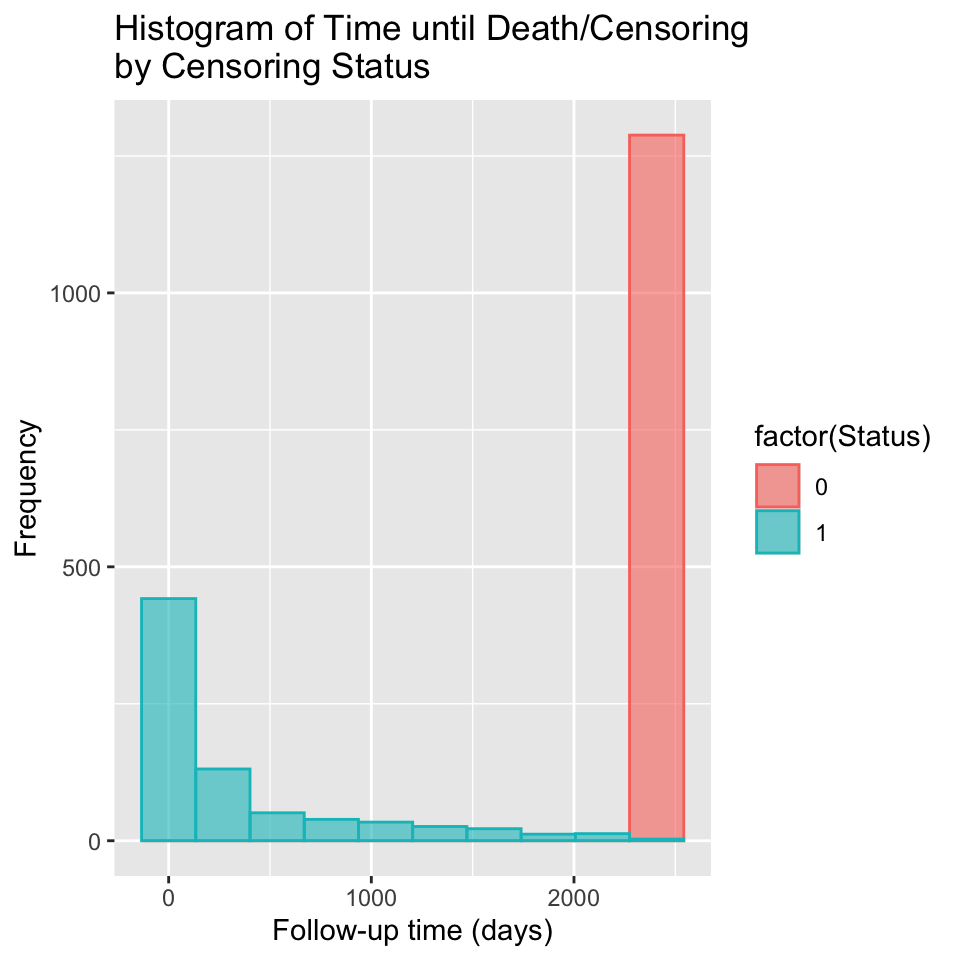

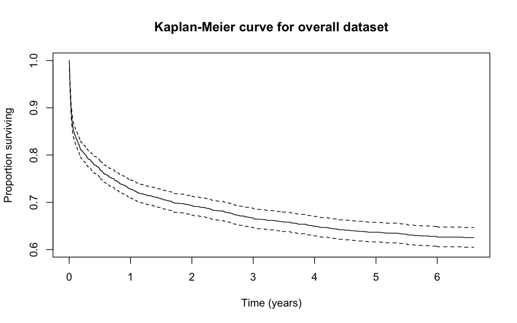

It may be inferred that the variables which have a significant impact on whether or not a patient dies in an ICU hospital (Age, ICU Type, SAPS1, SOFA, Albumin_max, AST_max, Bilirubin_max, BUN_max, Creatinine_max, GCS_max, Glucose_max, HCO3_max, HR_diff, Lactate_max, Na_diff, pH_diff, RespRate_max, Temp_diff, Urine_max, NISysABP_diff) also has a significant effect on survival time. The analysis below supports this.

```r
# Fit univariable model to assess significance of Age in survival
cox.Age <- coxph(Surv(Days,Status)~Age, data=icu_patients_df1)
summary(cox.Age)
```

```
## Call:
## coxph(formula = Surv(Days, Status) ~ Age, data = icu_patients_df1)
##
##   n= 2061, number of events= 773
##
##        coef exp(coef) se(coef)     z            Pr(>|z|)
## Age 0.03355   1.03412  0.00250 13.42 <0.0000000000000002 ***
## ---
## Signif. codes:  0 '***' 0.001 '**' 0.01 '*' 0.05 '.' 0.1 ' ' 1
##
##     exp(coef) exp(-coef) lower .95 upper .95
## Age     1.034      0.967     1.029     1.039
##
## Concordance= 0.646  (se = 0.01 )
## Likelihood ratio test= 209.4  on 1 df,   p=<0.0000000000000002
## Wald test            = 180.1  on 1 df,   p=<0.0000000000000002
## Score (logrank) test = 187  on 1 df,   p=<0.0000000000000002
```

Univariable model for age shows it is a significant predictor for survival. One year increase in age is associated with 3.41% increased risk of death, and p-value of less than 0.001 and 95% confidence interval not including 1 indicates this observed effect is statistically significant.

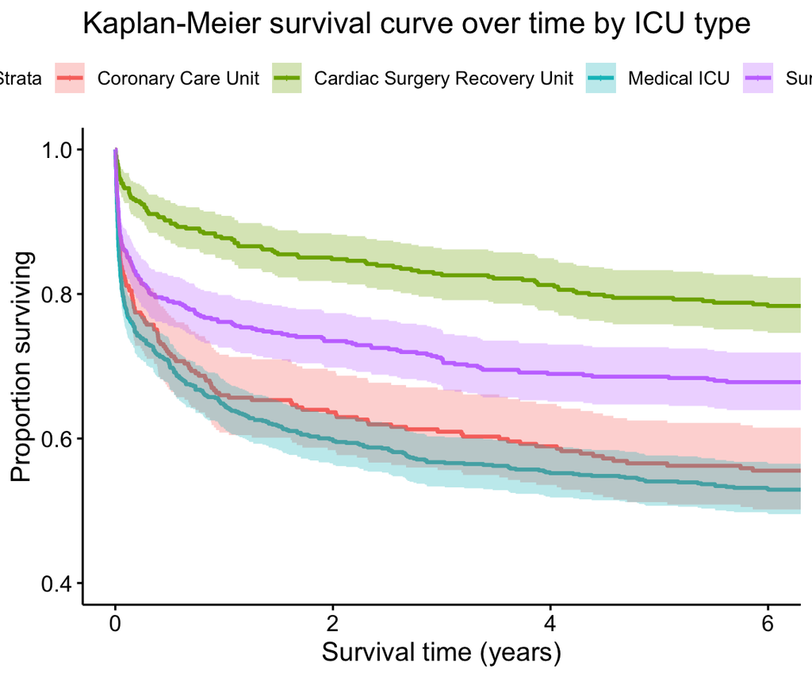

The Kaplan Meier curve by ICU type shows there is a significant difference in survival between the groups.

Overall survival

Mean (SD)

HR (univariable)

HR (multivariable)

15

SAPS1

15.0 (5.2)

1.07 (1.06-1.09, p<0.001)

1.03 (1.00-1.05, p=0.044)

16

SOFA

6.4 (4.2)

1.06 (1.05-1.08, p<0.001)

1.01 (0.98-1.04, p=0.596)

1

Albumin_max

3.0 (0.6)

0.82 (0.73-0.92, p<0.001)

0.90 (0.79-1.04, p=0.148)

2

AST_max

188.1 (765.8)

1.00 (1.00-1.00, p<0.001)

1.00 (1.00-1.00, p=0.041)

3

Bilirubin_max

1.7 (4.2)

1.03 (1.01-1.04, p=0.001)

1.02 (1.00-1.04, p=0.027)

4

BUN_max

27.5 (22.6)

1.02 (1.01-1.02, p<0.001)

1.01 (1.01-1.02, p<0.001)

5

Creatinine_max

1.5 (1.6)

1.11 (1.08-1.14, p<0.001)

0.93 (0.87-0.99, p=0.023)

6

GCS_max

12.9 (3.1)

0.92 (0.90-0.94, p<0.001)

0.94 (0.91-0.97, p<0.001)

7

Glucose_max

163.3 (88.5)

1.00 (1.00-1.00, p<0.001)

1.00 (1.00-1.00, p=0.520)

8

HCO3_max

24.3 (4.2)

0.98 (0.96-1.00, p=0.032)

1.01 (0.99-1.03, p=0.222)

9

HR_diff

30.4 (15.5)

1.01 (1.01-1.01, p<0.001)

1.00 (1.00-1.01, p=0.232)

10

Lactate_max

2.8 (2.2)

1.06 (1.03-1.09, p=0.001)

1.01 (0.97-1.06, p=0.570)

11

Na_diff

4.1 (3.7)

1.04 (1.03-1.06, p<0.001)

1.00 (0.98-1.02, p=0.934)

13

pH_diff

0.1 (0.1)

2.08 (1.51-2.86, p<0.001)

1.50 (0.89-2.52, p=0.130)

14

RespRate_max

29.1 (7.8)

1.01 (1.01-1.02, p=0.001)

1.00 (0.99-1.01, p=0.803)

18

Temp_diff

1.4 (0.8)

1.10 (1.01-1.21, p=0.034)

0.99 (0.88-1.10, p=0.817)

19

Urine_max

521.8 (508.5)

1.00 (1.00-1.00, p<0.001)

1.00 (1.00-1.00, p<0.001)

12

NISysABP_diff

37.8 (19.5)

1.01 (1.01-1.01, p<0.001)

1.00 (1.00-1.01, p=0.027)

17

strata(Age)

The low p-values indicate that the chosen clinical measures are also significant predictors.